# From deviations to linear models

Data Science and Predictive Machine Learning

## This lecture

- squared deviations
- linear modeling
- assumptions associated with the linear model

## We use the following packages

```r
library(dplyr)
library(magrittr)
library(ggplot2)
library(mice)
```

## Squared deviations

## We have already met deviations before

- correlations

\[\rho_{X,Y} = \frac{\mathrm{cov}(X,Y)}{\sigma_X\sigma_Y} = \frac{\mathrm{E}[(X - \mu_X)(Y-\mu_Y)]}{\sigma_X\sigma_Y}.\]

- t-test

\[t = \frac{\bar{X}-\mu}{\hat{\sigma}/\sqrt{n}}.\]

- variance

\[\sigma^2_X = \mathrm{E}[(X - \mu)^2].\]

## Deviations

Deviations tell what the distance is for each value (`observation`) to a comparison/reference value.

- often, the mean is chosen as a the reference.

### Why the mean?

The arithmetic mean is a very informative measure:

- it is the average
- it is the mathematical expectation
- it is the central value of a set of discrete numbers

\[ \] \[\text{The mean itself is a model: observations are}\] \[\text{merely a deviation from that model}\]

## The mean as a center

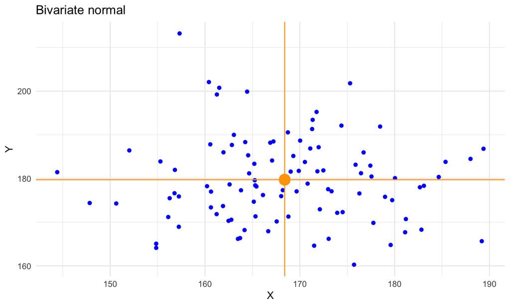

## Deviations from the mean

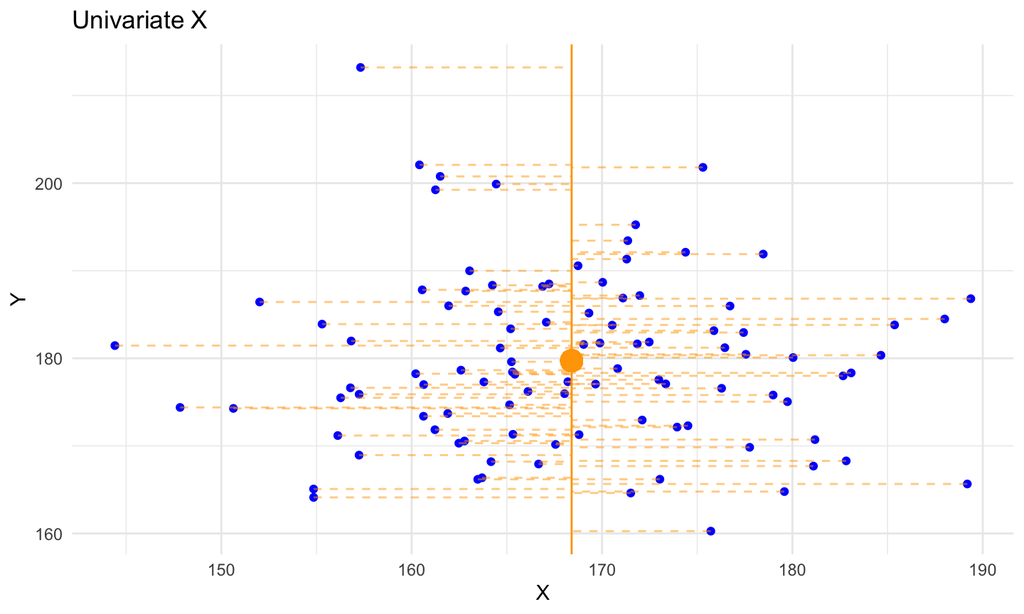

## Plotting the deviations

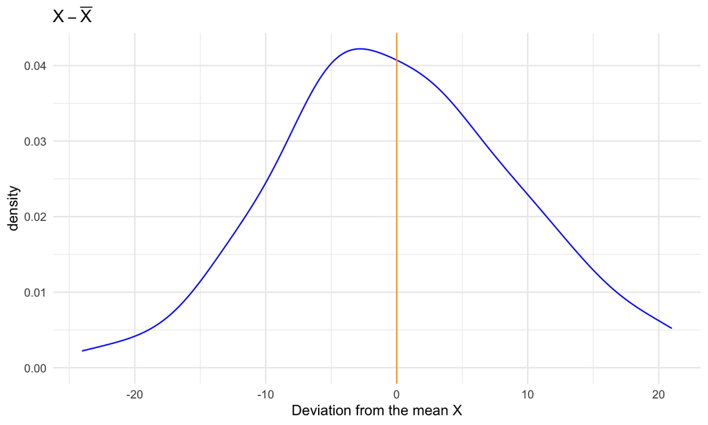

## Use of deviations

Deviations summarize the fit of all the points in the data to a single point

The mean is the mathematical expectation. It represents the observed values best for a normally distributed univariate set.

- The mean yields the lowest set of deviations

```r
plotdata %>%
  mutate("Mean" = X - mean(X),
         "Mean + 3" = X - (mean(X) + 3)) %>%
  select("Mean", "Mean + 3") %>%
  colSums %>%
  round(digits = 3)
```

```
##     Mean Mean + 3
##        0     -300
```

The mean minimizes the deviations

## What happens

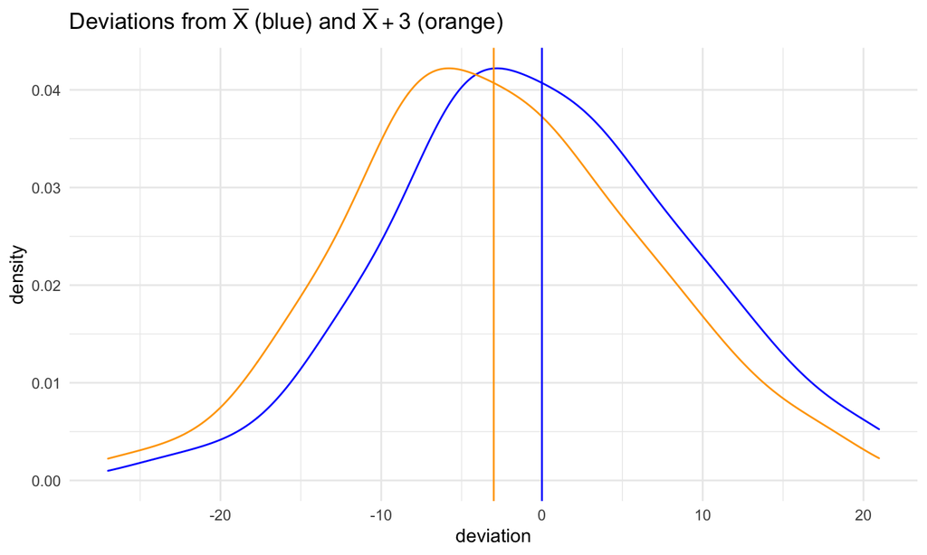

## Plotting the standardized deviations

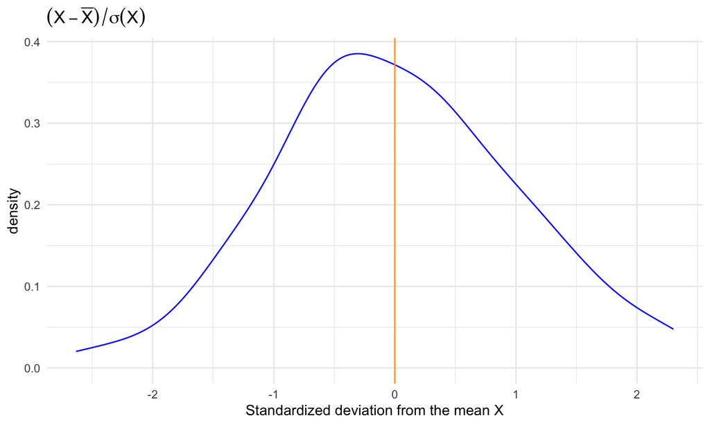

## Plotting the squared deviations

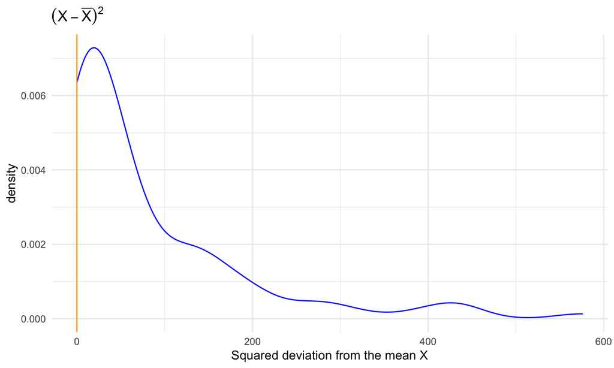

## Why squared deviations are useful

Throughout statistics we make extensive use of squaring. \[ \] \[\text{WHAT ARE THE USEFUL PROPERTIES OF SQUARING}\] \[\text{THAT STATISTICIANS ARE SO FOND OF?}\]

## Deviations from the mean

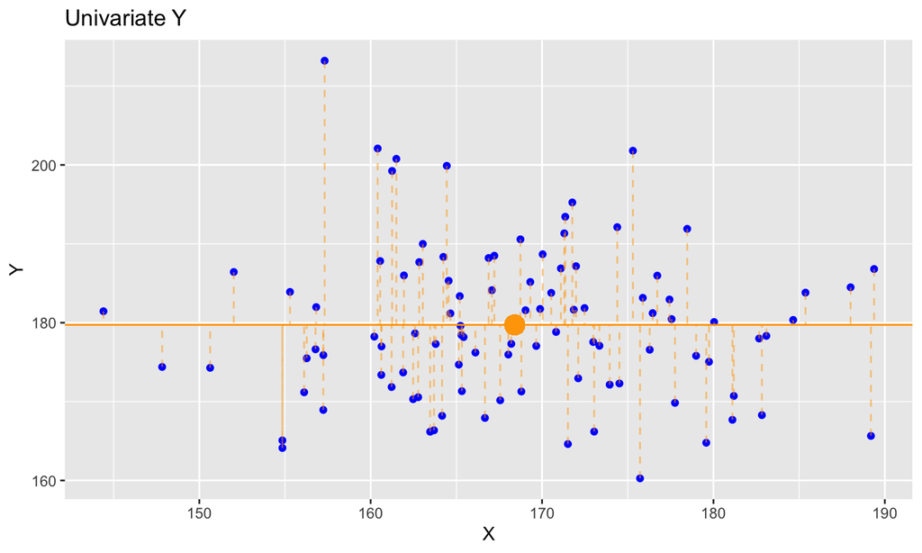

## Deviations from the mean

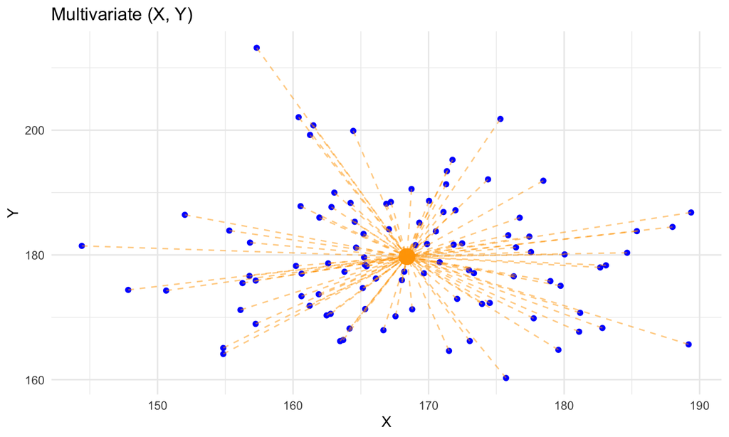

## Least squares solution

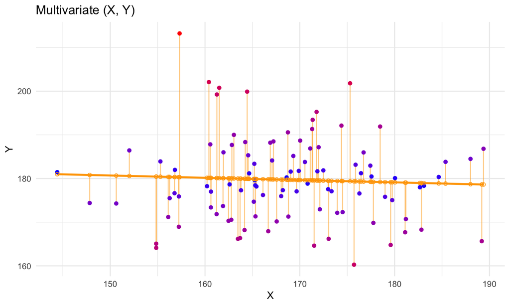

## Least squares solution

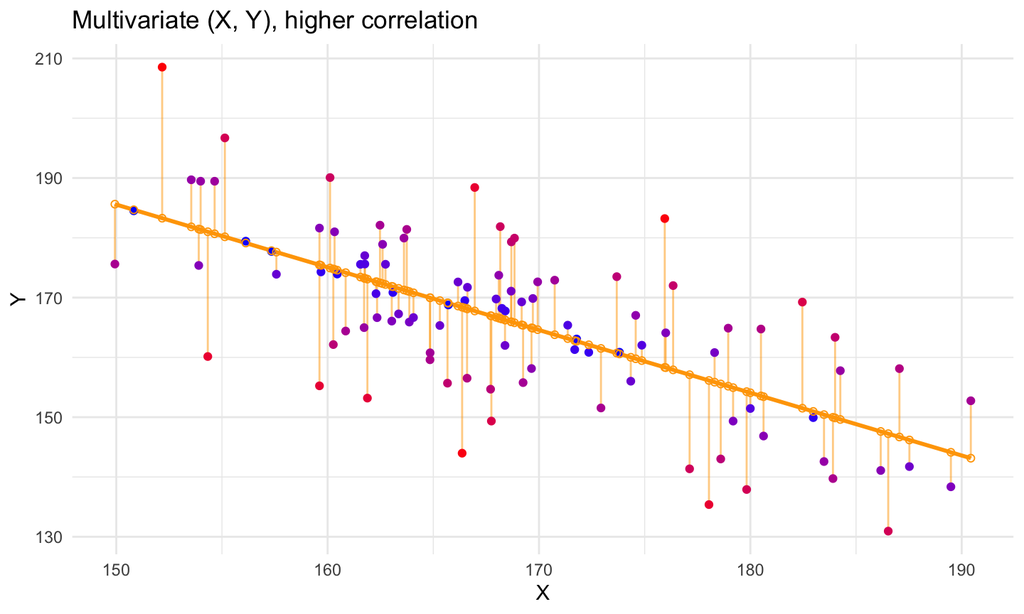

## Fitting a line to data

## Linear regression

Linear regression model \[ y_i=\alpha+\beta{x}_i+\varepsilon_i \]

Assumptions:

- \(y_i\) conditionally normal with mean \(\mu_i=\alpha+\beta{x}_i\)
- \(\varepsilon_i\) are \(i.i.d.\) with mean 0 and (constant) variance \(\sigma^2\)

## The `anscombe` data

```r
anscombe
```

```
##    x1 x2 x3 x4    y1   y2    y3    y4
## 1  10 10 10  8  8.04 9.14  7.46  6.58
## 2   8  8  8  8  6.95 8.14  6.77  5.76
## 3  13 13 13  8  7.58 8.74 12.74  7.71
## 4   9  9  9  8  8.81 8.77  7.11  8.84
## 5  11 11 11  8  8.33 9.26  7.81  8.47
## 6  14 14 14  8  9.96 8.10  8.84  7.04
## 7   6  6  6  8  7.24 6.13  6.08  5.25
## 8   4  4  4 19  4.26 3.10  5.39 12.50
## 9  12 12 12  8 10.84 9.13  8.15  5.56
## 10  7  7  7  8  4.82 7.26  6.42  7.91
## 11  5  5  5  8  5.68 4.74  5.73  6.89
```

## Fitting a line

```r
anscombe %>%
  ggplot(aes(y1, x1)) +
  geom_point() +
  geom_smooth(method = "lm")
```

## Fitting a line

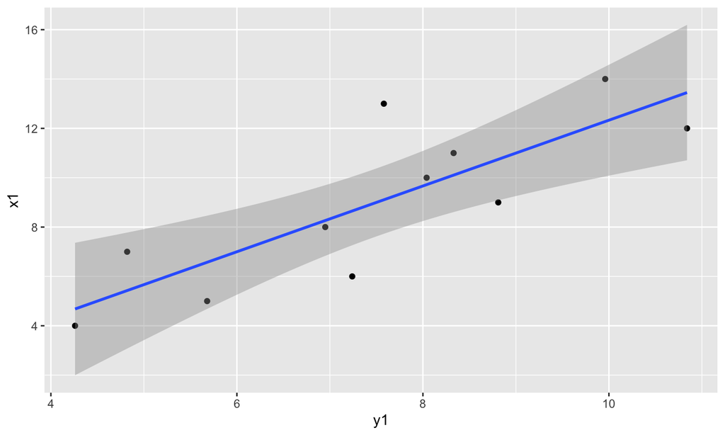

## Fitting a line

The linear model would take the following form:

```r
fit <-
  yourdata %>%
  lm(youroutcome ~ yourpredictors)

fit %>% summary() # pipe
summary(fit) # base R
```

Output:

- Residuals: minimum, maximum and quartiles
- Coefficients: estimates, SE’s, t-values and \(p\)-values
- Fit measures
  - Residuals SE (standard error residuals)
  - Multiple R-squared (proportion variance explained)
  - F-statistic and \(p\)-value (significance test model)

## `anscombe` example

```r
fit <- anscombe %$%
  lm(y1 ~ x1)

fit %>% summary
```

```
##
## Call:
## lm(formula = y1 ~ x1)
##
## Residuals:
##      Min       1Q   Median       3Q      Max
## -1.92127 -0.45577 -0.04136  0.70941  1.83882
##
## Coefficients:
##             Estimate Std. Error t value Pr(>|t|)
## (Intercept)   3.0001     1.1247   2.667  0.02573 *
## x1            0.5001     0.1179   4.241  0.00217 **
## ---
## Signif. codes:  0 '***' 0.001 '**' 0.01 '*' 0.05 '.' 0.1 ' ' 1
##
## Residual standard error: 1.237 on 9 degrees of freedom
## Multiple R-squared:  0.6665, Adjusted R-squared:  0.6295
## F-statistic: 17.99 on 1 and 9 DF,  p-value: 0.00217
```

## Assumptions

## The key assumptions

There are four key assumptions about the use of linear regression models.

In short, we assume

- The outcome to have a **linear relation** with the predictors and the predictor relations to be **additive**.
  - the expected value for the outcome is a straight-line function of each predictor, given that the others are fixed.
  - the slope of each line does not depend on the values of the other predictors
  - the effects of the predictors on the expected value are additive

  \[ y = \alpha + \beta_1X_1 + \beta_2X_2 + \beta_3X_3 + \epsilon\]
- The residuals are statistically **independent**
- The residual **variance is constant**
  - accross the expected values
  - across any of the predictors
- The residuals are **normally distributed** with mean \(\mu_\epsilon = 0\)

## A simple example

\[y = \alpha + \beta X + \epsilon\] and \[\hat{y} = \alpha + \beta X\] As a result, the following components in linear modeling

- outcome \(y\)
- predicted outcome \(\hat{y}\)
- predictor \(X\)
- residual \(\epsilon\)

can also be seen as columns in a data set.

## As a data set

As a data set, this would be the result for `lm(y1 ~ x1, data = anscombe)`

|  | y1 | y1.hat | residuals | x1 |
| --- | --- | --- | --- | --- |
| 1 | 8.04 | 8.001 | 0.038999999999999 | 10 |
| 2 | 6.95 | 7.00081818181818 | -0.0508181818181821 | 8 |
| 3 | 7.58 | 9.50127272727273 | -1.92127272727273 | 13 |
| 4 | 8.81 | 7.50090909090909 | 1.30909090909091 | 9 |
| 5 | 8.33 | 8.50109090909091 | -0.171090909090909 | 11 |
| 6 | 9.96 | 10.0013636363636 | -0.0413636363636357 | 14 |
| 7 | 7.24 | 6.00063636363636 | 1.23936363636364 | 6 |
| 8 | 4.26 | 5.00045454545455 | -0.740454545454545 | 4 |
| 9 | 10.84 | 9.00118181818182 | 1.83881818181818 | 12 |
| 10 | 4.82 | 6.50072727272727 | -1.68072727272727 | 7 |

[output cut: 1 more lines]

## An example

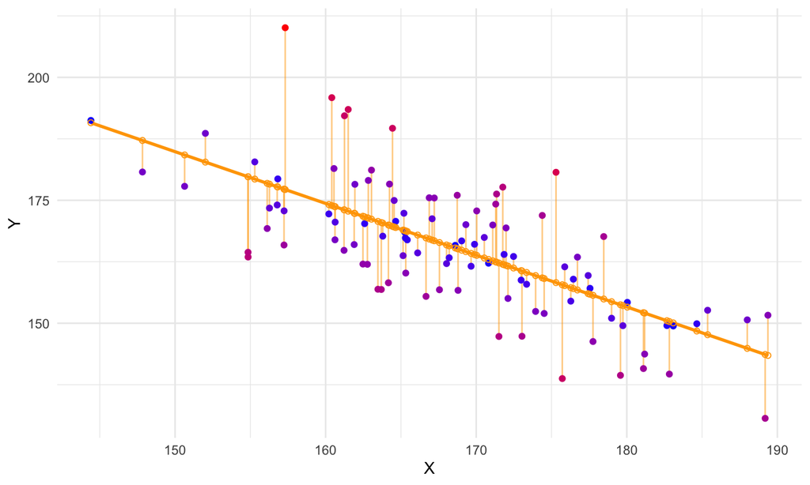

## Residual variance

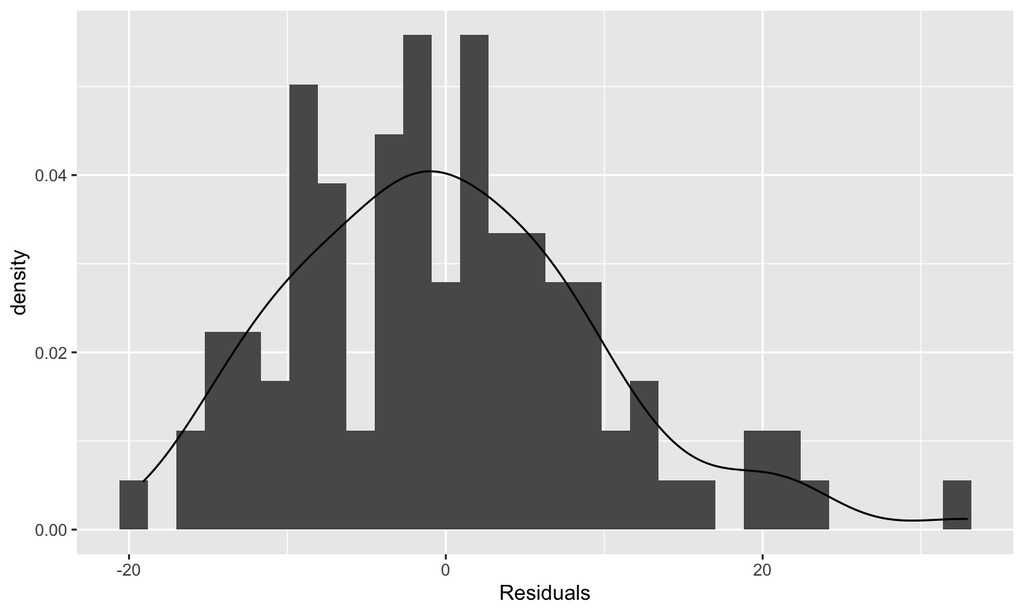

## Violated assumptions #1

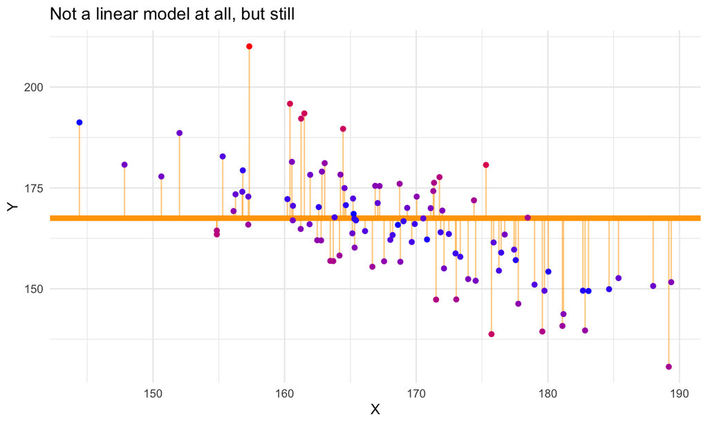

Here the residuals are not independent, and the residual variance is not constant!

## Residual variance

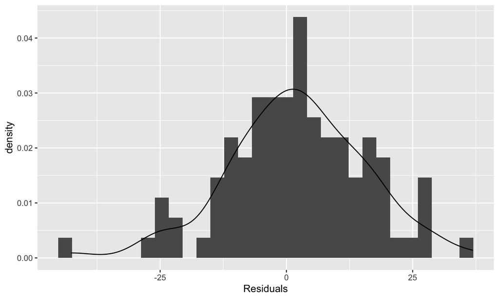

## Violated assumptions #2

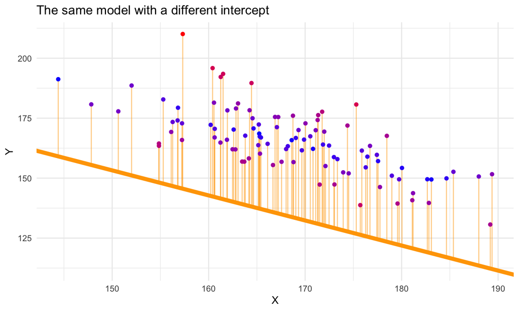

Here the residuals do not have mean zero.

## Residual variance

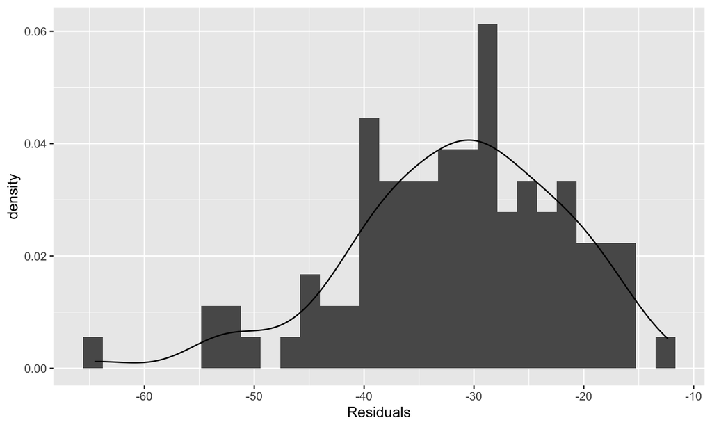

## Violated assumptions #3

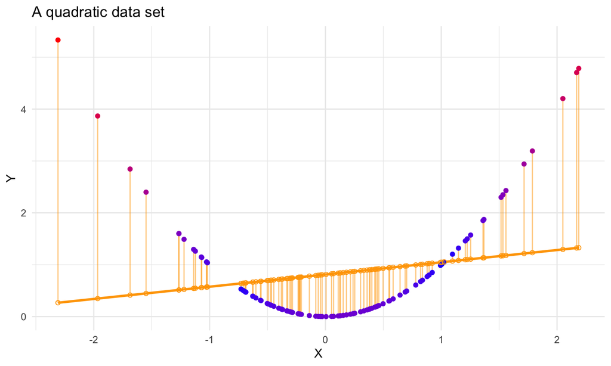

Here the residual variance is not constant, the residuals are not normally distributed and the relation between \(Y\) and \(X\) is not linear!

## Residual variance

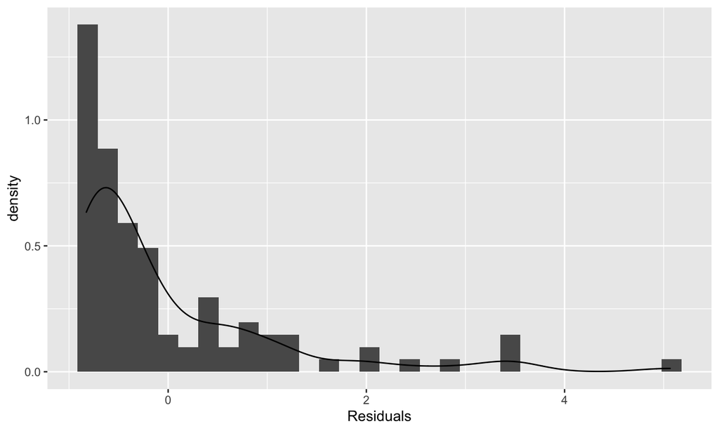

## Leverage and influence revisited

## Outliers and influential cases

Leverage: see the fit line as a lever.

- some points pull/push harder; they have more leverage

Standardized residuals:

- The values that have more leverage tend to be closer to the line
- The line is fit so as to be closer to them
- The residual standard deviation can differ at different points on \(X\) - even if the error standard deviation is constant.
- Therefore we standardize the residuals so that they have constant variance (assuming homoscedasticity).

Cook’s distance: how far the predicted values would move if your model were fit without the data point in question.

- it is a function of the leverage and standardized residual associated with each data point

## Fine

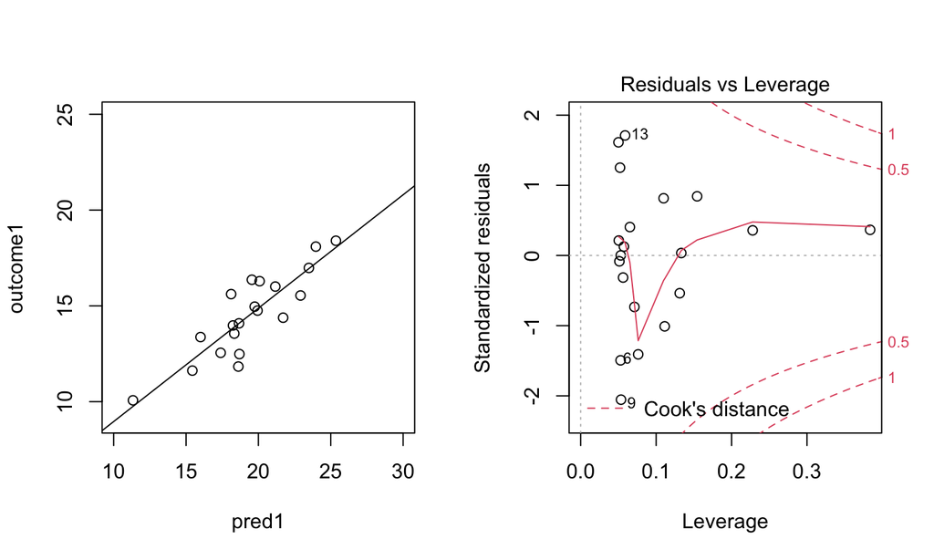

## High leverage, low residual

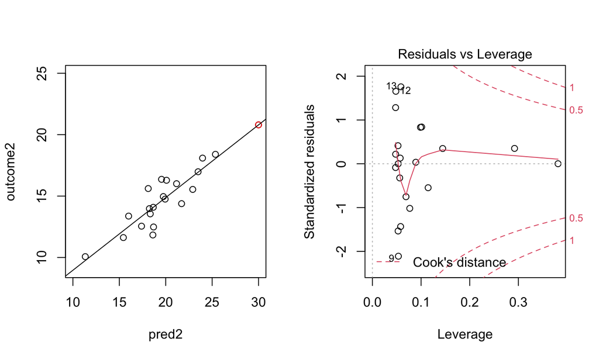

## Low leverage, high residual

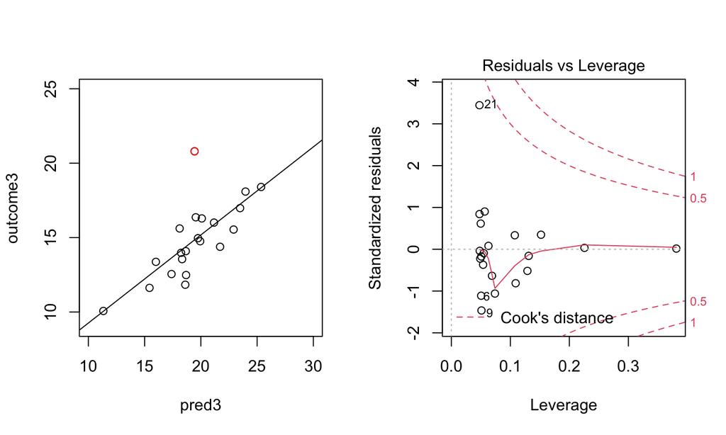

## High leverage, high residual

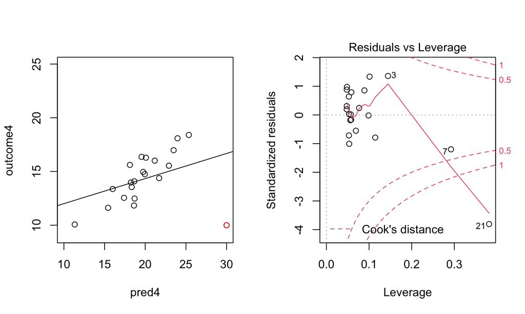

## Outliers and influential cases

Outliers are cases with large \(\epsilon_z\) (standardized residuals).

If the model is *correct* we expect:

- 5% of standardized residuals \(|\epsilon_z|>1.96\)
- 1% of standardized residuals \(|\epsilon_z|>2.58\)
- 0% of standardized residuals \(|\epsilon_z|>3.3\)

Influential cases are cases with large influence on parameter estimates

- cases with Cook’s Distance \(> 1\), or
- cases with Cook’s Distance much larger than the rest

## Outliers and influential cases

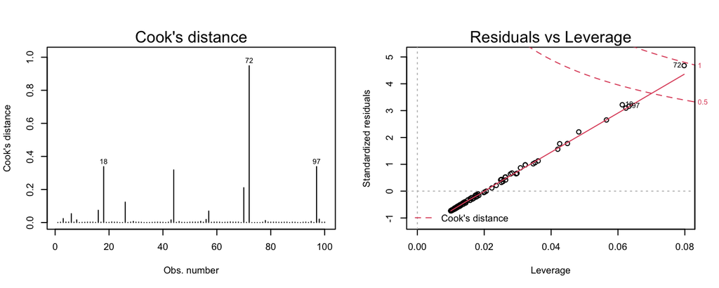

```r
par(mfrow = c(1, 2), cex = .6)
fit %>% plot(which = c(4, 5))
```

These are the plots for the `Violated Assumptions #3` scenario. There are many cases with unrealistically large \(|e_z|\), so these could be labeled as outliers. There are no cases with Cook’s Distance \(>1\), but case 72 stands out. Of course this model should have never been fit.